# Kodutöö 2

## Kodutöö esitamise õpetus

Iga ülesande lahendus peaks mahtuma ühte või mitmesse koodiaknasse, selle ülesande all. See kood võiks olla nii kirjutatud, et saaks käima tõmmata ilma mõtlemata. See tähendab, et kõik vajalikud lisapaketid ja andmestikud loetakse sisse vastavas koodiaknas.

Kahe viimase ülesande lahendused, mille puhul R kood pole vajalik, tuleks esitada lihtsalt samas zip kataloogis eraldi failina. Sellesse faili võib kirjutada õige faili nime mida vaadata.

Esita kogu kodutöö kataloog zip failina lehel https://courses.cs.ut.ee/2021/dataviz/spring/Main/Homework. Tähtaeg on **10. mai 23.59 EET**.

## Ülesanne 1

Teil tuleb noorem sugulane Tartusse ülikooli ja pole siin linnas kunagi käinud. Tehke talle üks väljaprinditav kaart, kus on teie arvates olulisemad asjad välja toodud (näiteks, õppehooned, ühika ümbruse poed, parimad lõbustusasutused, kõige olulisemad tänavad, …). Mõned asjad võiks kindlasti olla näidatud ka nimega. Kaart võiks olla visuaalselt puhas ja kena välja näha, nii et nimed oleks loetavad ja ei kattu, ei ole mingeid suvalisi teejuppe mis kuhugi ei vii. Kindlasti võiks peal olla ka jõgi.

```r
library(tidyverse)
library(sf)
library(osmdata)
library(leaflet)
library(ggrepel)
library(lwgeom)
```

```r
clean_osm_data = function(x, retain_named = F){
  for(i in names(x)){
    if(str_detect(i, "osm") & !is.null(x[[i]])){
      if(nrow(x[[i]]) == 0) { next}
      if(retain_named){
        x[[i]] = x[[i]] %>%
          filter(!is.na(name))
      }

      # res = x[[i]] %>% keep(~ mean(is.na(na_if(.x, ""))) < 0.2)
      res = x[[i]] %>% keep(function(.x) if(is.list(.x)){return(T)} else {mean(is.na(na_if(.x, ""))) < 0.2} )
      if(("name" %in% colnames(x[[i]])) & (!("name" %in% colnames(res)))){
        name = x[[i]] %>% as.data.frame() %>% select(name)
        res = res %>% bind_cols(name)
      }
      x[[i]] = res
    }
  }

  return(x)
}
```

```r
t_asutushooned
```

```
Simple feature collection with 2839 features and 12 fields
Geometry type: GEOMETRY
Dimension:     XY
Bounding box:  xmin: 26.70834 ymin: 58.36878 xmax: 26.74004 ymax: 58.38697
CRS:           EPSG:4326
First 10 features:
         osm_id.x addr.city addr.country addr.housenumber addr.street   building       name.x type osm_id.y name.y amenity                       geometry
30221555 30221555     Tartu           EE               24   Kroonuaia        yes         <NA> <NA>     <NA>   <NA>    <NA> POLYGON ((26.71476 58.38329...
30221557 30221557     Tartu           EE                3         Oru     school Joosepi maja <NA>     <NA>   <NA>    <NA> POLYGON ((26.71092 58.38214...
30221572 30221572     Tartu           EE               58      Kalevi        yes         <NA> <NA>     <NA>   <NA>    <NA> POLYGON ((26.73447 58.37018...
30221578 30221578     Tartu           EE             <NA>        <NA>        yes         <NA> <NA>     <NA>   <NA>    <NA> POLYGON ((26.70969 58.38298...
30221582 30221582     Tartu           EE               33  Aleksandri        yes         <NA> <NA>     <NA>   <NA>    <NA> POLYGON ((26.7337 58.37272,...
30221588 30221588     Tartu           EE               17   Kroonuaia        yes         <NA> <NA>     <NA>   <NA>    <NA> POLYGON ((26.71623 58.3837,...
30221598 30221598     Tartu           EE               12         Lai        yes         <NA> <NA>     <NA>   <NA>    <NA> POLYGON ((26.71707 58.38334...
30221604 30221604     Tartu           EE               54      Kalevi        yes         <NA> <NA>     <NA>   <NA>    <NA> POLYGON ((26.73438 58.37051...
30221616 30221616     Tartu           EE               3A        Aida        yes         <NA> <NA>     <NA>   <NA>    <NA> POLYGON ((26.73331 58.37249...
30221624 30221624     Tartu           EE               26   Kroonuaia apartments         <NA> <NA>     <NA>   <NA>    <NA> POLYGON ((26.71501 58.38316...
         Asutuse tüüp
30221555           NA
30221557           NA
30221572           NA
30221578           NA
30221582           NA
30221588           NA
30221598           NA
30221604           NA
30221616           NA
30221624           NA
```

## Ülesanne 2

Tehke samale sugulasele nüüd interaktiivne kaart. Kuna interaktiivne lahendus võimaldab sisse ja välja zoomida ning vajadusel täpsemat infot küsida, siis on võimalik panna peale rohkem infot. Lõpptulemusena võiks tekkida kaart millelt on võimalik leida kõik eluks vajalik. Sellele kaardil võiks olla vähemalt kolm kihti ja legend. Kindlasti tasub uurida ka erinevaid interaktiivseid võimalusi millest praksis ei jõudnud rääkida [<https://rstudio.github.io/leaflet/>](https://rstudio.github.io/leaflet/).

## Ülesanne 3

Kasutades Spotify populaarsete lugude andmestikku (Koduülesandest 5). Tehke nüüd interaktiivne visualisatsioon samast võrgustikust. Sellel shiny rakendusel peaks olema vähemalt 3 erinevat kontrolli, millega parameetreid muuta. Tulemuseks saadav rakendus peaks olema ilusti vormistatud, kontrollid olema sisukad, pilt selge ning kergesti loetav.

## Ülesanne 4

Andmestikus `occupations.RData` on info erinevate inimeste, sugude, vanuste, palkade ja ametite kohta. Kasutades `shinydashboard`-i tehke üks näidikutahvel mis võimaldaks uurida erinevate ametite keskmist palka, arvutada seda vabalt valitud vanusevahemikele ning valida kas vaadata seda sugude kaupa eraldi või koos. Iga ameti jaoks võiks olla võimalus visualiseerida palga jaotust selle ameti esindajate hulgas. Võiks olla välja toodud ka vähemalt 2 dünaamilist ja sisukat väärtuste kasti.

## Ülesanne 5

Andmestikus `birth_year.RData` on aasta päevade kaupa toodud ära keskmine sündide arv USAs. Proovige ÜHE graafikuga näidata selles andmestikus midagi huvitavat. Vormistage graafik nii, et see iseseisvalt annaks edasi sõnumi. Järgige selle töö käigus SWD protsessi ja lisaks pildile kirjutage sammude 2-5 kohta mida te iga sammu puhul konkreetselt tegite.

## Ülesanne 6

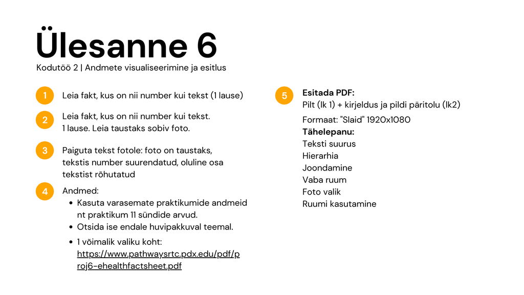

## Ülesanne 7

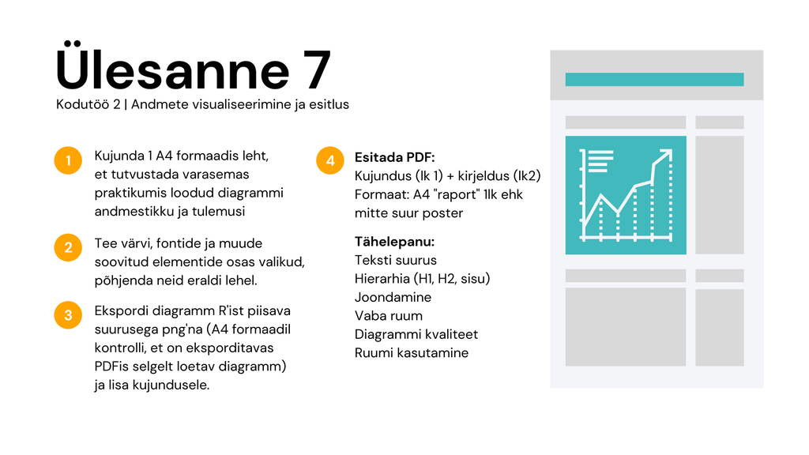